# Modeling Dwell Time to Predict Click-level Satisfaction

윤동규/Data Science

## Click Dwell Time & 논문 주제

- **사용자가 클릭한 결과에 대해 소요하는 시간**
- 클릭한 결과에 대한 만족도를 판단하는데 중요한 feature:  
  사용자가 특정 페이지에 더 시간을 보낼 수록, 그 컨텐츠에 만족할 가능성이 더 큼
- 하지만 페이지들은 많은 특성(예: 토픽, 가독성레벨, 컨텐츠길이 등)이 있으며, 이러한 특성들에 따라 사용자가 페이지에 대해 소요하는 시간이 크게 달라질수 있음
- **주제**: 페이지 특성들에 따른 click dwell time을 분석 및 예측하고, 이를 클릭 레벨에서의 만족도 예측에 활용

## 데이터 수집: Humal-Labeled Data(HLD)

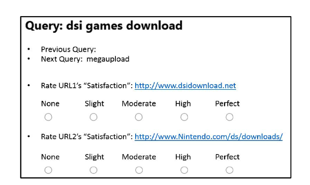

- 각 클릭별로 두 명의 annotator가 5단계의 점수를 매기고, SAT(만족)/DSAT(불만족) 판단
  - SAT: high, perfect, DSAT: moderate, slight, none
- 두 annotator의 SAT/DSAT이 일치하면 그 label을 쓰고, 불일치시 추가 annotator도 SAT/DSAT판단후 다수결로 결정

## 데이터 수집: Pseudo-Labeled Data(PLD)

- Humal-Labeled Data(HLD)만 사용하기에는 각각의 페이지 특성들에 해당하는 example 개수가 적으므로 Pseudo-Labeled Data(PLD) 데이터도 마련
- Query reformulation: 더 좋은 검색 결과를 얻기 위해 이전 검색 쿼리를 수정해서 다시 제출하는 것
- 각 클릭에 대해, 해당 클릭 다음에 query reformulation이 발생하면 DSAT, 그렇지 않으면 SAT으로 판별
- PLD는 모델 training 용도로만 사용, 모델 test는 HLD만 사용

## Click Dwell Time Model

1. Click Segment 생성
   - 쿼리-클릭 특성들에 기반하여 각 클릭 instance들을 segment(or group)로 카테고라이징
2. Model fitting
   - 각 클릭 segment별로 SAT/DSAT dwell time에 대한 probabilistic modelling & fitting

## Click Segment 생성: 쿼리-클릭 특성

1. 쿼리 토픽 특성:
   - query-based ODP (Open Directory Project)는 각 쿼리별로 가장 적합한 토픽 5개를 관련 확률과 함께 제공
   - 5개 토픽중 관련 확률이 0.5 이상인 토픽들만 사용
2. 쿼리 타입 특성:
   - 기존 연구[28]에서 사용한 쿼리 타입 카테고리를 바탕으로, PLD데이터에 학습하여 쿼리 타입 분류기 생성
   - ex) Homepage finding task, Technical help
3. 페이지 토픽 특성:
   - ODP 카테고리를 이용하여 클릭된 페이지 마다 토픽 label 부여
   - 기존 연구[41] 방법을 이용하면 URL만으로도 자동적으로 페이지를 토픽별로 분류가능
4. 가독 수준 특성:
   - 기존 연구[11]에서 주어진 문서의 reading difficulty 수준을 자동적으로 판별함
   - 각 문서의 가독 수준은 미국 학교의 학년 수준에 맞춰서 12개의 단계로 구분됨
5. 종합적으로 총 600개의 binary 특성을 추출
   - 219 쿼리 토픽 + 363 페이지 토픽 + 6 쿼리 타입 + 12 가독 수준

## Click Segment 생성: Decision Tree Learning

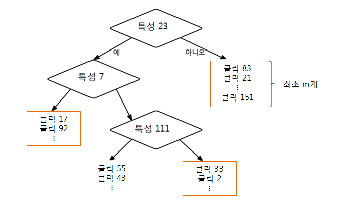

- 각 클릭 instance들은 600개의 binary 특성들이 있고, SAT/DSAT으로 labeled 되어있음
- 각 클릭 instance들의 SAT/DSAT을 분류하도록 binary desicion tree를 학습
- Desicion tree학습시 각 leaf node의 클릭 instance 개수는 최소 m개 이상
- SAT/DSAT decision rule = root로 부터 각 leaf node까지 도달하는 path

$\Rightarrow$ 클릭 segment 생성 rule

## Click Dwell Time Model

- 가정: 같은 click segment에 포함되는 click의 dwell time은 SAT/DSAT별로 같은 distribution을 따름 (Gamma distribution)
- Gamma distribution: 두 파라미터 shape $k>0$, scale $\theta>0$

$$p(t|k,\theta) = {t^{k-1} \over \Gamma(k)\theta^k} \exp(-{t \over \theta})$$

1. 각 클릭 segment에 대해 일단 그에 해당하는 클릭 example들을 수집하고
2. SAT/DSAT 별로 각 example들의 실제 dwell time 리스트$\{t\}_1^n$ 에 대해
3. SAT/DSAT 별로 MLE (Maximum Likelihood Estimation) 방식으로 gamma distribution의 두 파라미터 업데이트

$$\begin{eqnarray*}
\theta &=& {1 \over kn} \sum_{i=1}^n t_i \\
{1 \over k^(t+1)} &\gets& {1 \over k^(t)} + \frac{\ln k^{(t)} - \psi(k^{t}) - s}{(k^{(t)})^2(1/k^{(t)}) - \psi'(k^{(t)})}
\end{eqnarray*}$$

## Dwell Time Analysis

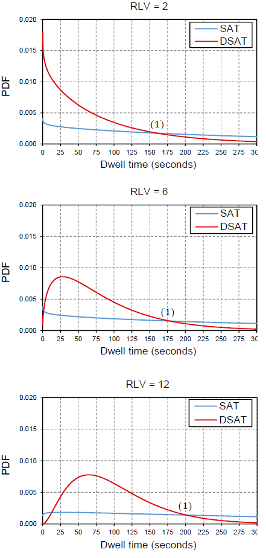

## Predicting SAT clicks

- SAT/DSAT dwell time distribution의 교차점을 threshold로 주어진 클릭의 SAT/DSAT 여부를 판단 가능
- 하지만 생성된 클릭 segment들이 모든 클릭 instance를 커버하지 못할 수 있으므로, statistical 한 방법으로 classification  
  ex) Multiple Additive Regression Trees (MART), SVM

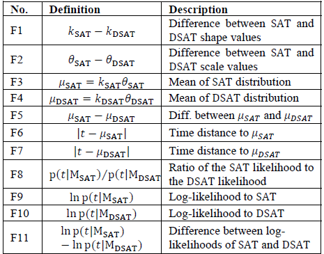

Dynamic dwell time features

## Evaluation

- HLD 데이터만 사용, MART regressor를 이용하여 각 클릭 instance의 SAT/DSAT 예측 & 평가
- Baseline1: 각 클릭 instance의 dwell time 뿐
- Baseline2: 600개의 binary feature + 검색 성능 예측에 대한 기존 work에서 사용한 feature들
- Baseline3: Baseline 1 + 2
- D: Dynamic dwell time features, R: 클릭 segmentation rule

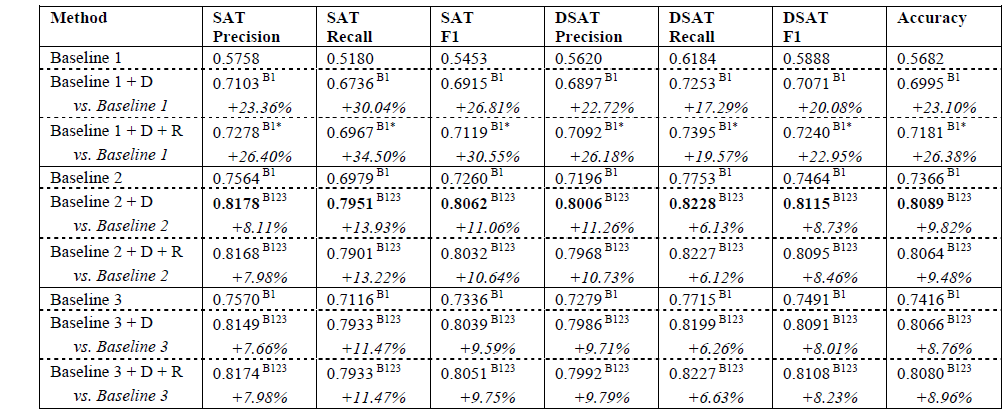